# Novoalign Testing Report

Muhamad Amir Hafizin

17 August, 2016

# BASIC COMMAND

- Reference Gene: Arabidopsis thaliana.TAIR10
  - 119,146,348 bp
  - 121.7 MB -> 2.6 GB
- Build using the ART
- Using time -verbose
- Cite
  - Hatem A., Bozdag D., Toland A.E., Catalyurek U.V.Benchmarking short sequence mapping tools. BMC Bioinform. 2013;14:184.
  - Thole J.M., Beisner E.R., Liu J., Venkova S.V., Strader L.C. Abscisic acid regulates root elongation through the activities of auxin and ethylene in Arabidopsis thaliana. G3 (Bethesda) 2014;4:1259–1274. doi: 10.1534/g3.114.011080

## ART

- ART is use to produce a simulated fastq and SAM file from the reference sequence by emulating the sequencing process either illumina,ART-454 or SOLiD.
- The coding for Building is:
  - art_illumina -ss HS20 -sam -i refseq -l 100 -f 10 -o ilumina
    - “-ss” = The name of Illumina sequencing system of the built-in profile used for simulation
    - “HS20” = sequencing system ID names for HiSeq 2000 (100bp)
    - “sam” = indicate to generate SAM alignment file
    - “i” = the filename of input DNA/RNA reference
    - “l” = the length of reads to be simulated
    - “f” = the fold of read coverage to be simulated or number of reads/read pairs generated for each amplicon
    - “o” = the prefix of output filename

## NOVOINDEX

- Novoindex is use to index the target reference sequence before the the alignment is done.
- The coding use
  - novoindex thaliana.idx Arabidopsis thaliana.TAIR10.fa
    - The option of the NovoIndex is been left as default(the option is default is as below suggested)
    - k = 11
    - s = 1

## NOVOALIGN

- The coding use
  - The NovoAlign is the In-house Aligner that were use to mapped the fastq sequence file with the reference sequence.
  - Novoalign -c 5 -t 10 -f ilumina.fq -d thaliana.idx -o SAM 2> novoalign.stderr > parameter.sam
    - “c” = Sets number of threads to use.
    - “t” = Sets the maximum alignment score acceptable for the best alignment.
    - “d” = Full pathname of indexed reference sequence created by novoindex
    - “o” = Specifies the report name and format
- The basic infomation of the result
  - Elapsedtime = time from start to finish the process based on the real time.
  - time user = the amount of CPU time used when execute the process only.(outside kernel){user mode}
  - time system = the amount of CPU time used when execute the process include the other process(within the kernel){kernel mode}
  - CPU percent = the amount of percentage of CPU core been used
  - Unique aligment = the mapped region that been mapped only to that location
  - Multimapped = the mappped region that been mapped multiple time
  - No Mapping = the region that been unmapped.

# Table

| Threshold..t. | control | t0 | t10 | t20 | t30 | t40 | t50 | t60 | t70 | t80 | t90 | t100 | t110 | t120 | t130 | t140 | t150 | t160 |
| --- | --- | --- | --- | --- | --- | --- | --- | --- | --- | --- | --- | --- | --- | --- | --- | --- | --- | --- |
| Elapsedtime (min) | 8.45 | 1.31 | 5.16 | 6.31 | 7.12 | 7.58 | 8.25 | 9.30 | 9.30 | 9.40 | 9.70 | 9.60 | 9.20 | 9.70 | 9.11 | 9.60 | 9.60 | 9.60 |
| Time User (min) | 44.12 | 8.16 | 26.18 | 33.10 | 35.35 | 39.25 | 42.20 | 44.17 | 44.10 | 44.35 | 44.43 | 44.59 | 44.80 | 44.35 | 44.31 | 44.36 | 44.54 | 44.45 |
| Time System (sec) | 6.29 | 8.22 | 6.35 | 6.47 | 6.36 | 6.18 | 6.38 | 6.38 | 6.13 | 6.34 | 6.09 | 6.27 | 6.35 | 6.17 | 6.27 | 6.39 | 6.35 | 6.24 |
| CPU Percent | 490.00 | 435.00 | 484.00 | 487.00 | 487.00 | 488.00 | 488.00 | 487.00 | 489.00 | 489.00 | 489.00 | 489.00 | 488.00 | 487.00 | 488.00 | 488.00 | 489.00 | 489.00 |
| One Cpu Percent use | 97.00 | 86.00 | 96.00 | 97.00 | 97.00 | 97.00 | 97.00 | 96.00 | 97.00 | 97.00 | 97.00 | 97.00 | 97.00 | 96.00 | 97.00 | 97.00 | 97.00 | 97.00 |
| percent is average for all | 8.37 | 1.30 | 5.19 | 6.28 | 7.18 | 7.45 | 9.31 | 9.32 | 9.18 | 9.36 | 9.55 | 9.48 | 9.25 | 9.57 | 9.19 | 9.50 | 9.48 | 9.48 |
| Time for One Cpu(min) | 43.36 | 7.55 | 26.19 | 32.20 | 36.10 | 40.60 | 41.51 | 45.56 | 45.51 | 45.49 | 46.00 | 45.52 | 45.44 | 45.46 | 45.15 | 45.58 | 46.00 | 45.53 |
| Unique Aligment | 11503474.00 | 498444.00 | 5492123.00 | 8962386.00 | 10345426.00 | 11022579.00 | 11337187.00 | 11447727.00 | 11485040.00 | 11498007.00 | 11501925.00 | 11503018.00 | 11503361.00 | 11503439.00 | 11503459.00 | 11503465.00 | 11503466.00 | 11503466.00 |
| Unique Aligment Percent | 96.30 | 4.20 | 46.00 | 75.00 | 86.60 | 92.30 | 94.90 | 95.80 | 96.10 | 96.20 | 96.30 | 96.30 | 96.30 | 96.30 | 96.30 | 96.30 | 96.30 | 96.30 |
| Multi Mapped | 443449.00 | 19239.00 | 211655.00 | 345293.00 | 398779.00 | 424785.00 | 436997.00 | 441244.00 | 442642.00 | 443208.00 | 443361.00 | 443386.00 | 443404.00 | 443406.00 | 443406.00 | 443407.00 | 443408.00 | 443408.00 |
| Multi Mapped Percent | 3.70 | 0.20 | 1.80 | 2.90 | 3.30 | 3.60 | 3.70 | 3.70 | 3.70 | 3.70 | 3.70 | 3.70 | 3.70 | 3.70 | 3.70 | 3.70 | 3.70 | 3.70 |
| No Mapping | 2.00 | 11429242.00 | 6243147.00 | 2639246.00 | 1202720.00 | 499561.00 | 172741.00 | 57954.00 | 19243.00 | 5710.00 | 1639.00 | 521.00 | 160.00 | 80.00 | 60.00 | 53.00 | 51.00 | 51.00 |
| No Mapping percent | 0.00 | 95.70 | 52.30 | 22.10 | 10.10 | 4.20 | 1.40 | 0.50 | 0.20 | 0.00 | 0.00 | 0.00 | 0.00 | 0.00 | 0.00 | 0.00 | 0.00 | 0.00 |

# Graph

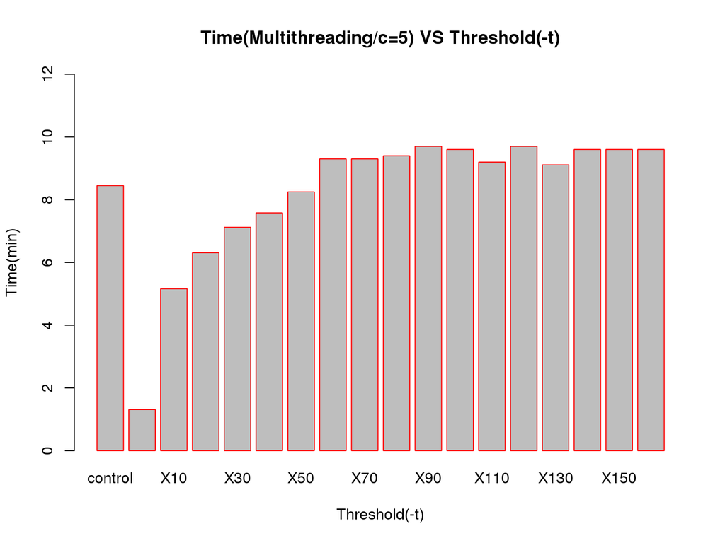

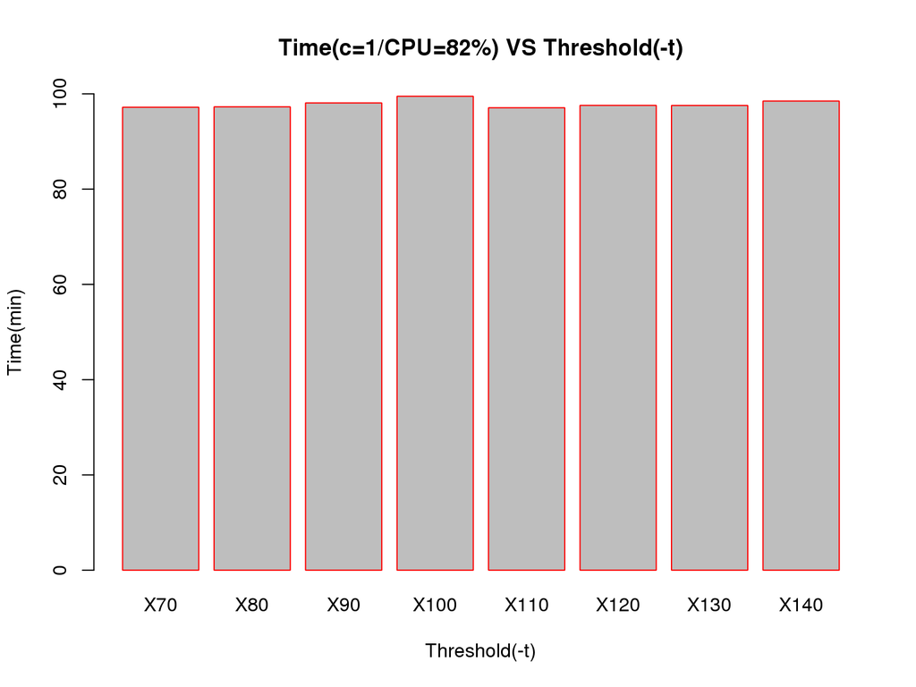

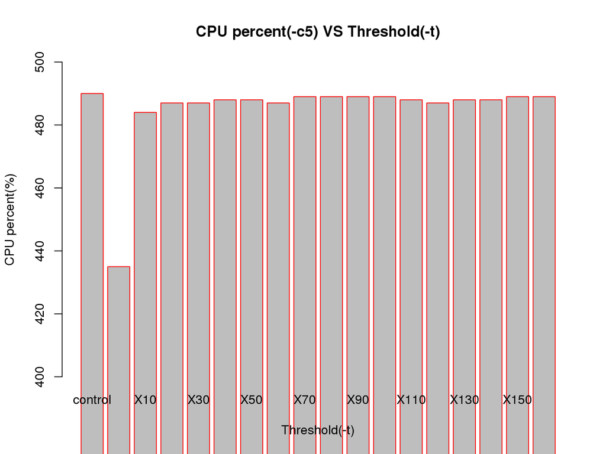

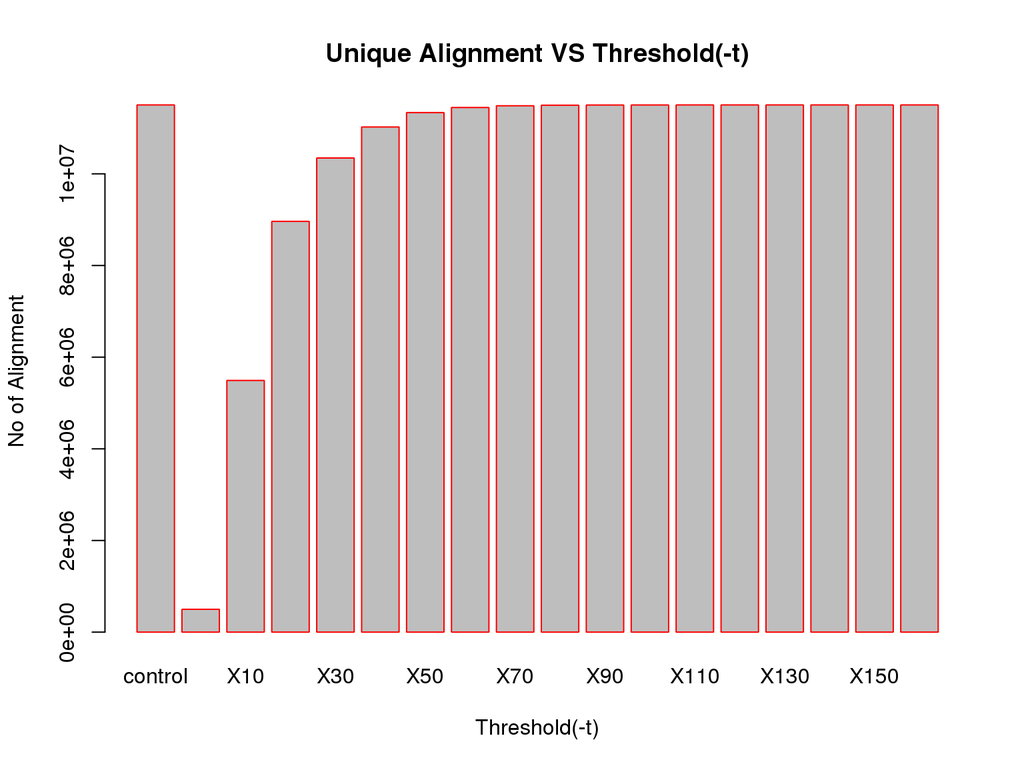

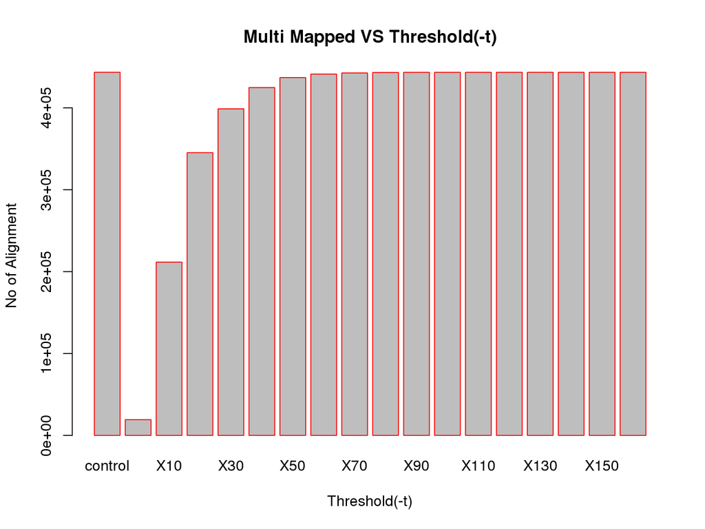

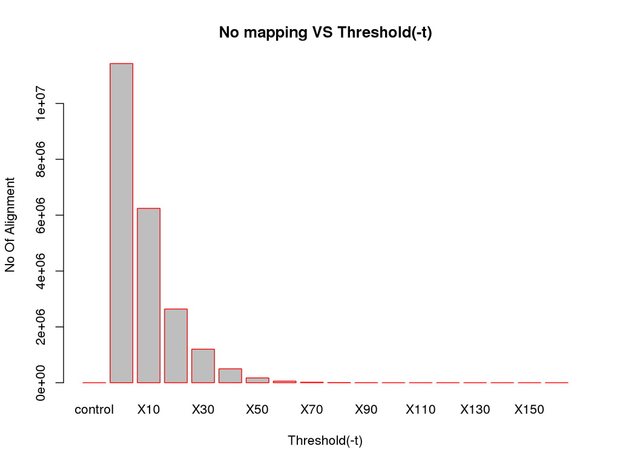

# Table

## Based on the Qualimap (QC for the Mapped region)

- Basic Information
  - mapped read = the basepair that been align/mapped according to the Novoalign log file.
  - unmapped read = the basepair that has not been align/mapped accoridng to Novoalign log file
  - inside region = region of interest based on the reference sequence
  - outside region = outside of region of interest based on the reference sequence
  - mapped read (inside region) = the basepair that been align/mapped according to qualimap
  - mean mappin (inside region) = the mean mapping quality of the mapped reads
  - standard deviation (inside region) = S.D of the mapped reads
  - general error (inside region) = ratio of total collected edit distance to the number of mapped bases
  - mismatches (inside region) = wrong mapped number of start or stop position when mapped the fastq based on reference sequence
  - insertion (inside region) = the different nucleotide composition from the reference sequence that has more basepaird
  - deletion (inside region) = the different nucleotide composition from the reference sequence tha has less basepair
  - mapped read (outside region) = the basepair that been align/mapped according to qualimap
  - mean mappin (outside region) = the mean mapping quality of the mapped reads
  - standard deviation (outside region) = S.D of the mapped reads
  - general error (outside region) = ratio of total collected edit distance to the number of mapped bases
  - mismatches (outside region) = wrong mapped number of start or stop position when mapped the fastq based on reference sequence
  - insertion (outside region) = the different nucleotide composition from the reference sequence that has more basepaird
  - deletion (outside region) = the different nucleotide composition from the reference sequence tha has less basepair

[output not shown]

[figure not shown]